# Practical Machine Learning Writeup

Wolfgang Ecker-Lala

Friday, November 20, 2015

# Introduction

A group of enthusiasts who take measurements about themselves regularly to improve their health provided data collected with devices like **Jawbone Up**, **Nike FuelBand** and **Fitbit**. The data and more information is available on http://groupware.les.inf.puc-rio.br/har.

Goal of this course project is to predict the manner in which they did the exercise. Therefore a training dataset has been provided at https://d396qusza40orc.cloudfront.net/predmachlearn/pml-training.csv. Based on this dataset the variable *classe* should be predicted.

After some prediction models could be found they could be tested using following dataset: https://d396qusza40orc.cloudfront.net/predmachlearn/pml-testing.csv

# Data Loading, Manipulation & Exploration

After downloading the training and testing datasets into a user defined working directory the data can be loaded using

```r
training <- read.table("pml-training.csv",stringsAsFactors=FALSE,sep=",",header=TRUE,na.strings = c("NA", "#DIV/0!", ""))
```

The structur of the training dataset is following:

```r
str(training)
```

```
## 'data.frame':    19622 obs. of  160 variables:
##  $ X                       : int  1 2 3 4 5 6 7 8 9 10 ...
##  $ user_name               : chr  "carlitos" "carlitos" "carlitos" "carlitos" ...
##  $ raw_timestamp_part_1    : int  1323084231 1323084231 1323084231 1323084232 1323084232 1323084232 1323084232 1323084232 1323084232 1323084232 ...
##  $ raw_timestamp_part_2    : int  788290 808298 820366 120339 196328 304277 368296 440390 484323 484434 ...
##  $ cvtd_timestamp          : chr  "05/12/2011 11:23" "05/12/2011 11:23" "05/12/2011 11:23" "05/12/2011 11:23" ...
##  $ new_window              : chr  "no" "no" "no" "no" ...
##  $ num_window              : int  11 11 11 12 12 12 12 12 12 12 ...
##  $ roll_belt               : num  1.41 1.41 1.42 1.48 1.48 1.45 1.42 1.42 1.43 1.45 ...
##  $ pitch_belt              : num  8.07 8.07 8.07 8.05 8.07 8.06 8.09 8.13 8.16 8.17 ...
##  $ yaw_belt                : num  -94.4 -94.4 -94.4 -94.4 -94.4 -94.4 -94.4 -94.4 -94.4 -94.4 ...
##  $ total_accel_belt        : int  3 3 3 3 3 3 3 3 3 3 ...
##  $ kurtosis_roll_belt      : num  NA NA NA NA NA NA NA NA NA NA ...
##  $ kurtosis_picth_belt     : num  NA NA NA NA NA NA NA NA NA NA ...
##  $ kurtosis_yaw_belt       : logi  NA NA NA NA NA NA ...
```

[output cut: 86 more lines]

We see that it is a very large dataframe with dimension

```r
dim(training)
```

```
## [1] 19622   160
```

The frequencies of exercises not dependent on the user is

```r
table(training$classe)
```

```
##
##    A    B    C    D    E
## 5580 3797 3422 3216 3607
```

The frequencies of exercises dependet on each user is

```r
table(training$user_name,training$classe)
```

```
##
##               A    B    C    D    E
##   adelmo   1165  776  750  515  686
##   carlitos  834  690  493  486  609
##   charles   899  745  539  642  711
##   eurico    865  592  489  582  542
##   jeremy   1177  489  652  522  562
##   pedro     640  505  499  469  497
```

It is not hard to see that exercise **A** is the preferred exercise.

Nevertheless we do not intend to make a user dependent prediction and so the first 6 columns can be removed.

```r
trainData<-training[,7:dim(training)[2]]
```

At the end columns which have mostly value **NA** will be removed.

```r
keepColumns<-apply(!is.na(trainData), 2, sum)==(dim(training)[1])
trainData<-trainData[,keepColumns]
```

So the new training dataset has following dimension:

```r
dim(trainData)
```

```
## [1] 19622    54
```

For **cross validation purposes** the trainingset has to be splitted into two sets.

```r
library(caret)
set.seed(4711)
trainIndex <- createDataPartition(y=trainData$classe, p=0.60, list=FALSE)
trainData1  <- trainData[trainIndex,]
trainData2  <- trainData[-trainIndex,]

dim(trainData1)
```

```
## [1] 11776    54
```

```r
dim(trainData2)
```

```
## [1] 7846   54
```

In the next step *“near zero covariates”* will be removed.

```r
nzvColumns <- nearZeroVar(trainData1)
if(length(nzvColumns) > 0) {
  trainData1 <- trainData1[, -nzvColumns]
  trainData2 <- trainData2[, -nzvColumns]
}
dim(trainData1)
```

```
## [1] 11776    54
```

## Simple Correlation Analysis

A simple correlation analysis gives following result:

```r
corMatrix<-cor(trainData1[,1:dim(trainData1)[2]-1])
diag(corMatrix)<-0
colOfInterest <- which(corMatrix>.8,arr.ind=TRUE)
dim(colOfInterest)
```

```
## [1] 18  2
```

```r
corrAttributes <- matrix(c(rownames(colOfInterest),colnames(corMatrix[,colOfInterest[,2]])),nrow=dim(colOfInterest)[1],ncol=2,byrow=FALSE)
corrAttributes
```

```
##       [,1]               [,2]
##  [1,] "yaw_belt"         "roll_belt"
##  [2,] "total_accel_belt" "roll_belt"
##  [3,] "accel_belt_y"     "roll_belt"
##  [4,] "roll_belt"        "yaw_belt"
##  [5,] "roll_belt"        "total_accel_belt"
##  [6,] "accel_belt_y"     "total_accel_belt"
##  [7,] "magnet_belt_x"    "accel_belt_x"
##  [8,] "roll_belt"        "accel_belt_y"
##  [9,] "total_accel_belt" "accel_belt_y"
## [10,] "accel_belt_x"     "magnet_belt_x"
## [11,] "magnet_arm_x"     "accel_arm_x"
## [12,] "accel_arm_x"      "magnet_arm_x"
## [13,] "magnet_arm_z"     "magnet_arm_y"
## [14,] "magnet_arm_y"     "magnet_arm_z"
## [15,] "accel_dumbbell_x" "pitch_dumbbell"
## [16,] "accel_dumbbell_z" "yaw_dumbbell"
## [17,] "pitch_dumbbell"   "accel_dumbbell_x"
## [18,] "yaw_dumbbell"     "accel_dumbbell_z"
```

We see that *“yaw_belt”* and *“roll_belt”* are highly correlated.

## Principal Component Analysis

The **“Principal Component Analysis”** shows that only 8 predictors are necessary.

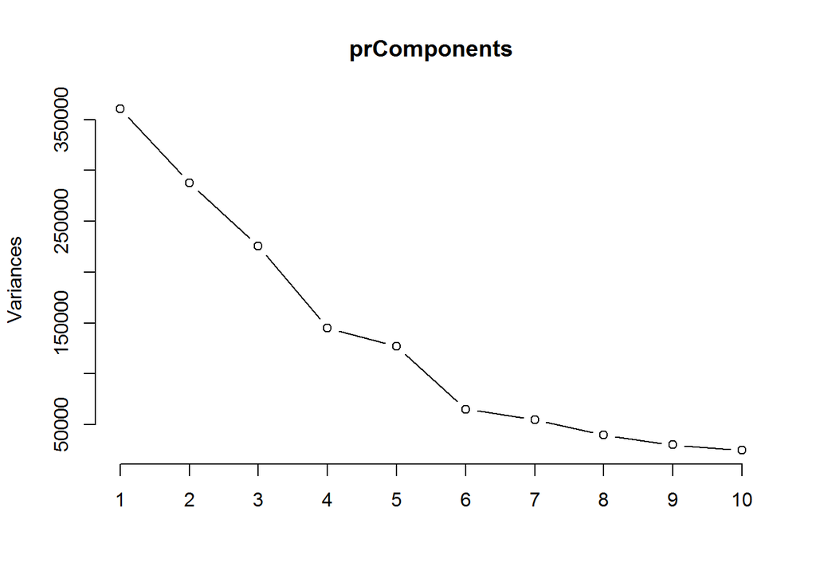

```r
prComponents<-prcomp(trainData1[,1:dim(trainData1)[2]-1])
plot(prComponents,type="l")
```

# Modeling

Out of the gained knowledge from the analysis it is time to build the model. I have chosen the **RANDOM FOREST** algorithm for running the prediction.

```r
library(randomForest)
library(caret)
set.seed(4711)
preProc<-preProcess(trainData1[,1:dim(trainData1)[2]-1],method="pca",pcaComp=8)
trainPC<-predict(preProc,trainData1[,1:dim(trainData1)[2]-1])
```

As the calculation lasted several hours I show the training calculation as text. So next step is

**fitModel <- train(trainData1$classe~.,data=trainPC,method=“rf”,prox=TRUE,allowPrallel=TRUE)**

And than I saved the model in order to be able to reuse it.

**saveRDS(fitModel, “pml_modelRF.Rds”)**

## CROSS-VALIDATION

In order to test how accurate the model is the second dataset has been used.

```r
fitModel <- readRDS("pml_modelRF.Rds")

testPC<-predict(preProc,trainData2[,1:dim(trainData1)[2]-1])
evalResult<-predict(fitModel,testPC)
```

The confusion matrix shows the accuracy of the chosen model.

```r
confusionMatrix(trainData2$classe,evalResult)
```

```
## Confusion Matrix and Statistics
##
##           Reference
## Prediction    A    B    C    D    E
##          A 2129   26   40   30    7
##          B   35 1359   80   29   15
##          C   44   45 1239   24   16
##          D   23   12   66 1177    8
##          E    9   28   36   31 1338
##
## Overall Statistics
##
##                Accuracy : 0.923
##                  95% CI : (0.9169, 0.9288)
##     No Information Rate : 0.2855
##     P-Value [Acc > NIR] : < 2.2e-16
##
##                   Kappa : 0.9026
##  Mcnemar's Test P-Value : 5.448e-10
##
## Statistics by Class:
##
##                      Class: A Class: B Class: C Class: D Class: E
## Sensitivity            0.9504   0.9245   0.8480   0.9117   0.9668
## Specificity            0.9816   0.9751   0.9798   0.9834   0.9839
## Pos Pred Value         0.9539   0.8953   0.9057   0.9152   0.9279
## Neg Pred Value         0.9802   0.9825   0.9657   0.9826   0.9928
## Prevalence             0.2855   0.1874   0.1862   0.1645   0.1764
## Detection Rate         0.2713   0.1732   0.1579   0.1500   0.1705
## Detection Prevalence   0.2845   0.1935   0.1744   0.1639   0.1838
## Balanced Accuracy      0.9660   0.9498   0.9139   0.9475   0.9753
```

## OUT-OF-SAMPLE ERROR RATE

First the function missClassification was defined in order to provide an easy way to calculate the out-of-sample error rate several times.

```r
missClassification <- function(values, predicted) {
  sum(predicted != values) / length(values)
}
```

And the calculation of the out-of-sample error rate shows

```r
OOS_errRate <- missClassification(trainData2$classe, evalResult)
OOS_errRate
```

```
## [1] 0.0769819
```

that the out-of-sample error rate is quite good.

# SUBMISSION

At the end the testing dataset for submission was predicted.

```r
testPC2<-predict(preProc,testData[,1:dim(testData)[2]-1])
evalResultTest<-predict(fitModel,testPC2)

testData$classe <- evalResultTest
```

A function for creating the resultset file was defined.

```r
pml_write_files = function(x){
  n = length(x)
  for(i in 1:n){
    filename = paste0("problem_id_",i,".txt")
    write.table(x[i],file=filename,quote=FALSE,row.names=FALSE,col.names=FALSE)
  }
}
```

The result was prepared for submission.

```r
submitData <- data.frame(problem_id = testData$problem_id, classe = evalResultTest)
```

The file was created.

```r
write.csv(submitData, file = "./submitfiles/pml_coursera_submission.csv", row.names = FALSE)
```

And finally I got **20 of 20** points.